# Ethics 2: Live Session 2

Author

Zak Varty

- Summary and further exploration of the topics covered this week.

## Accumulated Local Effects Plot

Consider a model $f(x, y, z;\theta)$ with:

- three predictors $X$, $Y$, and $Z$,
- fitted parameter values $\hat \theta$,
- estimated using on $n$ observations: $\{(x_i, y_i, z_i), a_i\}$.

### ICE plots

Individual conditional expectation plots show the counter-factual prediction of the outcome as one predictor is varied for each individual.

$$f_i(x; \hat \theta) = f(x, y_i, z_i; \hat\theta).$$

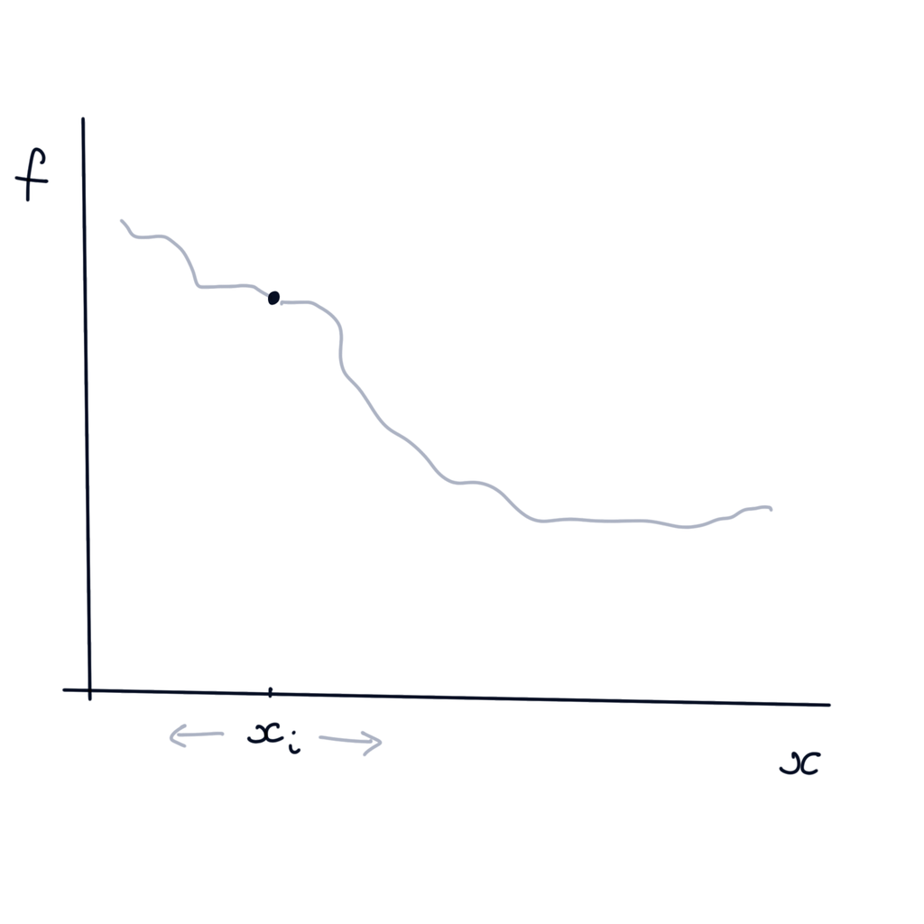

We can construct 1 such ICE plot per observation or person within our dataset.

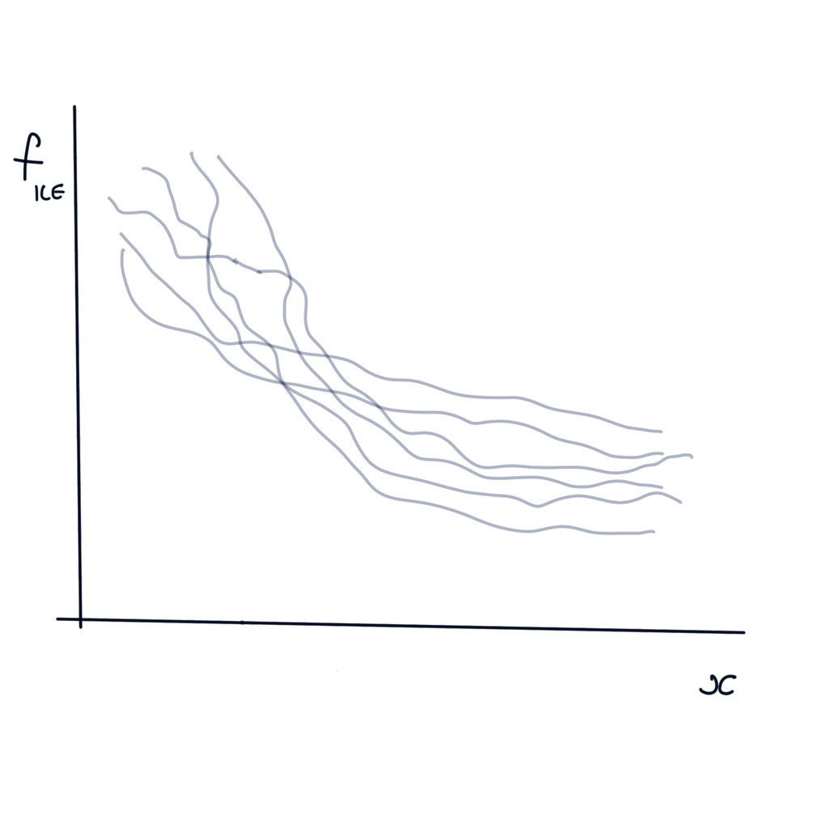

We have to be careful about extrapolating to unreasonable combinations $(x,y,z)$. Just because we can make a prediction doesn’t mean we should.

In the example below, increasing x to 1 while keeping y fixed does not seem reasonable.

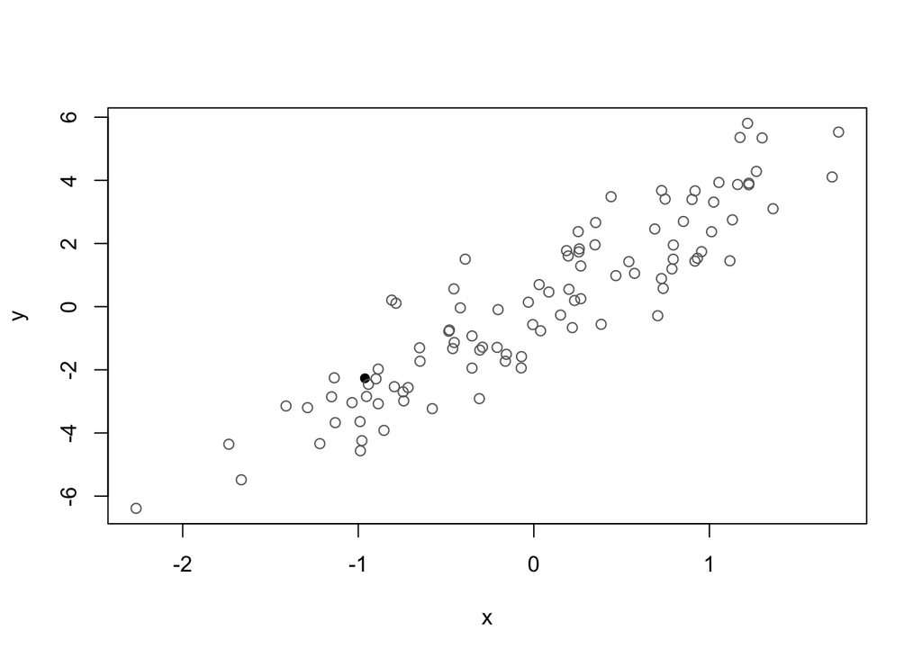

These sorts of checks rapidly get harder in higher dimensions.

### PDPs

Partial dependence plots, which you met last week show the expected response as a function of one predictor, **averaged over the values of all other covariates**.

So in our example the PDP for $X$ would be:

$$f_{pdp}(x;\hat\theta) = \mathbb{E}_{Y,Z}[f (x, Y, Z; \hat \theta)] \approx \frac{1}{n} \sum_{i=1}^n \hat f(x, y_i, z_{i}).$$

PDPs can be considered as the expected (or point wise mean) of the ICE curves.

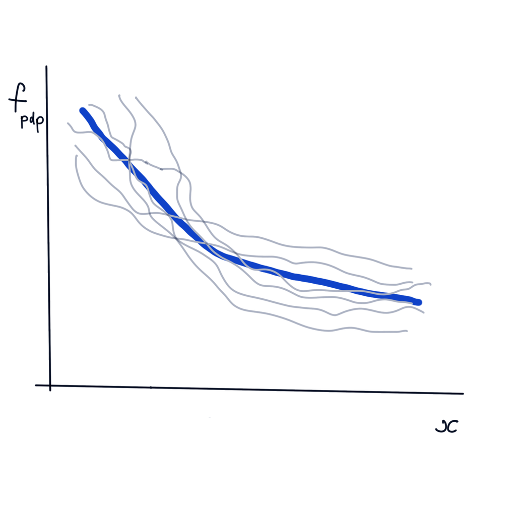

- While this describes how a response changes on average, that does not mean we expect any individual ICE cure to look anything like the PDP.

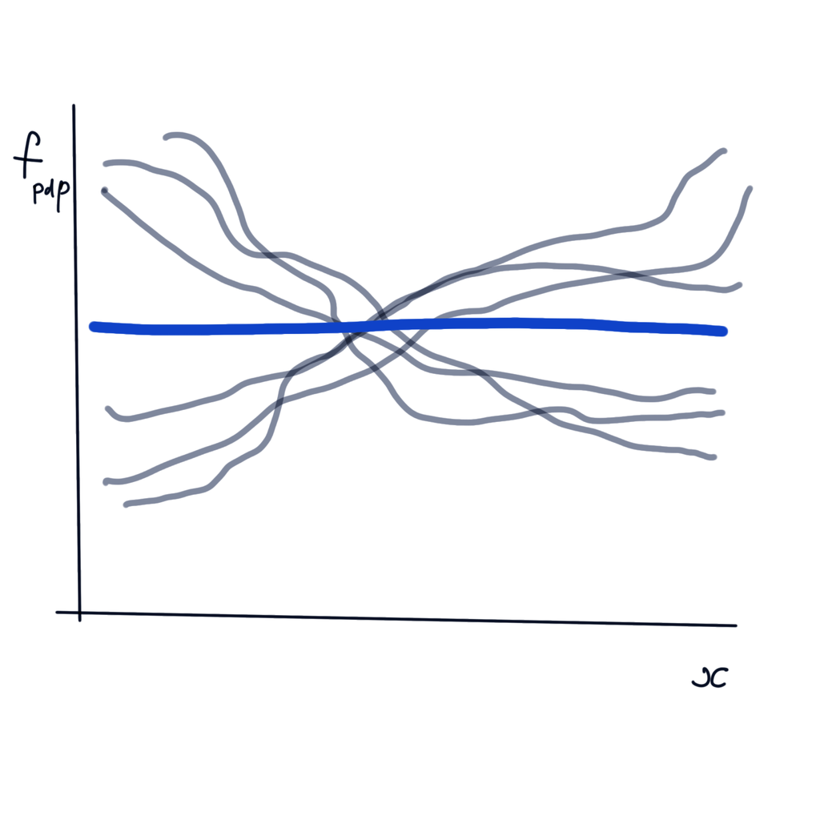

Similar to ICEs we have to be careful about extrapolating / interpolating with PDPs to low-density regions of predictor space.

If $X$ is independent of $Y$ and $Z$ the above expectation makes sense, it assumes that all of the observed $y$ and $z$ values could be observed alongside any $x$ value in our pdp with equal probability.

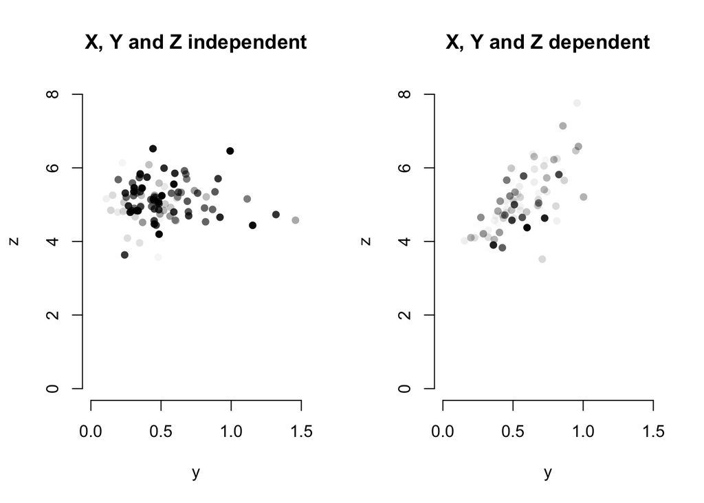

If we return to our trees example, this is clearly not the case - from context we know that a tree with very large volume is also likely to be taller.

### M-plots

$$f_M(x; \hat \theta) = \mathbb{E}_{Y,Z|X=x}[f (x, Y, Z; \hat \theta)]$$

To evaluate this conditional expectation, we only consider observations that have $X$ values close to each $x$ we consider: that is those points in $B_x(\delta) = \{x' : |x' - x| < \delta\}$.

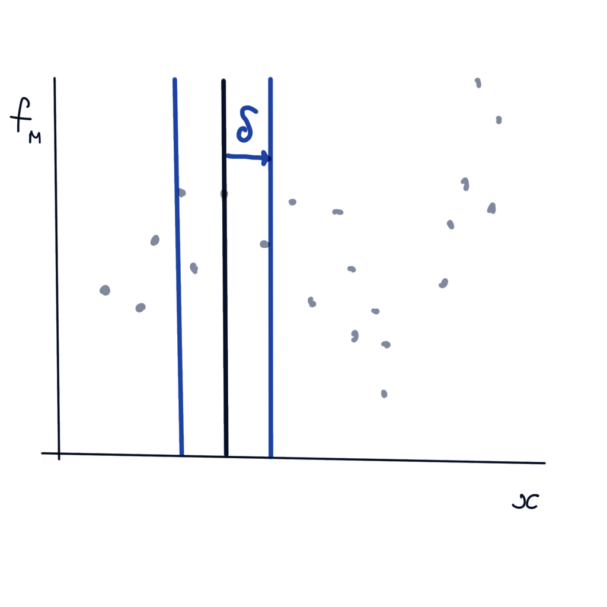

**Question:** What do we have to balance when picking $\delta$?

So we approximate the conditional expectation by:

$$f_M(x;\hat\theta) = \mathbb{E}_{Y,Z|X=x}[f (x, Y, Z; \hat \theta)] \approx \frac{1}{N(B_x(\delta))} \sum_{\{i: x_i \in B_x(\delta)\}} f(x, y_i, z_i; \hat\theta),$$

where $N(S)$ denotes the number of observations lying in subset $S$ of the predictor space.

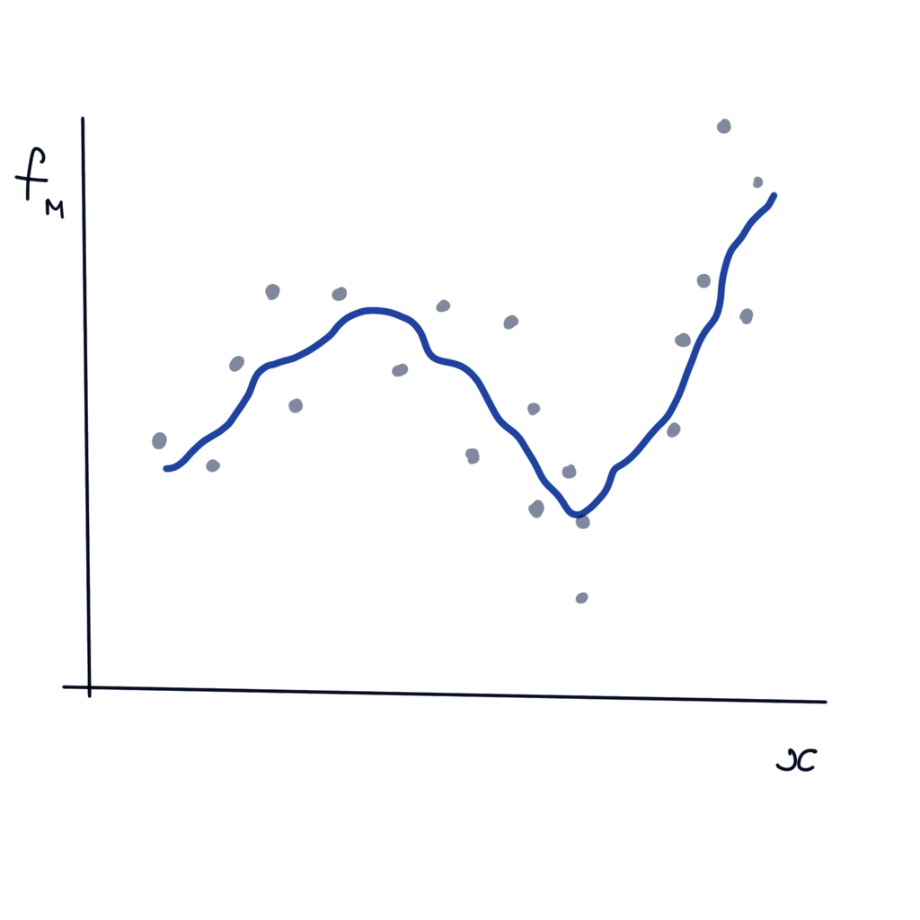

### ALE plots

Rather than only basing our estimate on the small number of points that have $X$ values close to $x$, we instead use all observations that have values less than $x$.

To do that we:

- Find $x_0 \leq \min x_i$
- Split $(x_0, x)$ into $m$ intervals $I_1, \ldots, I_m$ of length $\epsilon_1, \ldots, \epsilon_m$
  - standard case has all intervals of equal length
- Find the average value of $\partial f / \partial x$ using the data points in each interval
  - this gives us an estimate of how increasing x over that range changes our response
- Multiply each estimate by the interval length and add them up
  - this gives us an estimate of the cumulated effect of a particular $x$ value on our response.

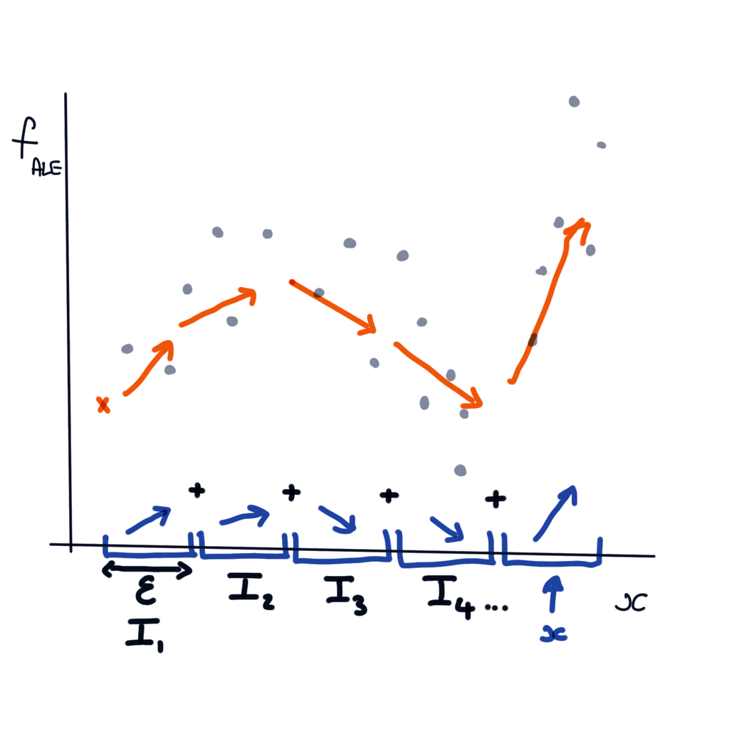

Mathematically we can express this as $J = \lceil(x - x_0)/\epsilon\rceil$ be the index of the first interval endpoint that is above $x$

$$f_{ALE}(x) = \sum_{j = 0}^J \underset{\text{ average } \partial f / \partial x \text{ for observations in } I_{j+1}}{\underbrace{\left( \frac{1}{N(I_{j+1})} \sum_{\{i:x_i \in I_{j+1}\}} \frac{\hat f(x_0 + (j+1)\epsilon, y_i, z_i) - \hat f(x_0 + j\epsilon, y_i, z_i) }{\epsilon}\right)}}.$$

This leads us to many similar considerations about the width of the intervals.

- If we have dense observations of $x$, then lots of small intervals will better approximate $\partial f / \partial x$ and so better construct the ALE plot.
- If we have few observations in one interval then we have a very noisy estimate of $\partial f / \partial x$, which effects all the ALE at all higher values.
- If we have no observations in one interval, we cannot estimate the gradient there at all!
- **Simple solution:** adaptive interval widths to maintain equal sample sizes for gradient estimation.

### Predictive vs Prognostic covariates

> A **prognostic** biomarker provides information about the patient’s overall cancer outcome, regardless of therapy.

> A **predictive** biomarker gives information about the effect of a therapeutic intervention.

Consider the following model: `outcome ~ age * sex * treatment`

**Question:** Which of the following terms are prognostic and which are predictive?

- `1`
- `age`
- `sex`
- `treatment`
- `age:sex`
- `age:treatment`
- `sex:treatment`
- `age:sex:treatment`

### Interactions in decision trees

> In general a decision tree with depth $k$ will include k-way interaction terms.

**Question:** Why is this?

### SHAP Quiz

**Question:** Can anyone explain a SHAP value?

**Question:** Can anyone explain how SHAP interactions extend this?

**Question:** Why is this difficult?